# r-homework-2

Riley Maher

Novmeber 8, 2020

# Homework Assignment 2

## Import Packages

```r
library("ggplot2")
library("dplyr")
memory.limit(size=50000)
```

```
## [1] 50000
```

```r
memory.size(max=TRUE)
```

```
## [1] 79.75
```

## Using sample CSV

```r
# Reading in the sample CSV I made
total_sample <- read.csv('sample.csv', stringsAsFactors = TRUE)
head(total_sample)
```

```
##   tripduration                starttime                 stoptime
## 1          564 2019-04-11 07:44:36.0580 2019-04-11 07:54:00.1840
## 2         1158 2019-05-15 18:00:33.3890 2019-05-15 18:19:52.0150
## 3          763 2019-03-25 13:27:50.4260 2019-03-25 13:40:33.7960
## 4          915 2019-06-21 15:52:07.8340 2019-06-21 16:07:23.6810
## 5         1368 2019-06-01 18:42:22.9500 2019-06-01 19:05:11.7510
## 6          267 2019-07-31 18:47:05.5630 2019-07-31 18:51:33.0870
##   start.station.id       start.station.name start.station.latitude
## 1             3711       E 13 St & Avenue A               40.72967
## 2             3016        Kent Ave & N 7 St               40.72037
## 3              382  University Pl & E 14 St               40.73493
## 4              359       E 47 St & Park Ave               40.75510
## 5             3295 Central Park W & W 96 St               40.79127
## 6             3377     Carroll St & Bond St               40.67861
##   start.station.longitude end.station.id  end.station.name end.station.latitude
## 1               -73.98068            168   W 18 St & 6 Ave             40.73971
## 2               -73.96165           3016 Kent Ave & N 7 St             40.72037
## 3               -73.99201            459  W 20 St & 11 Ave             40.74674
## 4               -73.97499            483   E 12 St & 3 Ave             40.73223
## 5               -73.96484           3142   1 Ave & E 62 St             40.76123
## 6               -73.99037           3398   Smith St & 9 St             40.67470
##   end.station.longitude bikeid   usertype birth.year gender
## 1             -73.99456  29807 Subscriber       1994      1
## 2             -73.96165  34411 Subscriber       1974      1
## 3             -74.00776  16078 Subscriber       1961      1
## 4             -73.98890  29904 Subscriber       1964      2
## 5             -73.96094  30247   Customer       1969      0
## 6             -73.99786  20315 Subscriber       1971      1
```

I had to do this because my computer kept crashing.

## Initial Data Exploration

### Gender Split

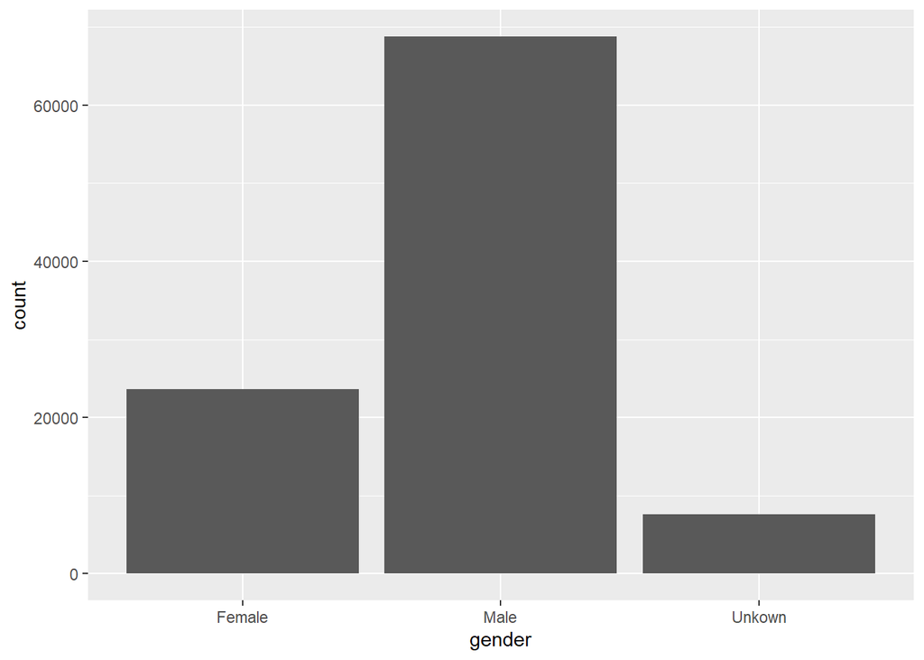

```r
# Reclassifying the genders
# 0=unknown, 1=male, 2=female
total_sample$gender <- ifelse(total_sample$gender == 0, "Unkown",
                                  ifelse(total_sample$gender == 1, "Male", "Female"))

# Seeing the split of genders who rented bikes
gender_split <- ggplot(total_sample, aes(x=gender)) + geom_bar()
gender_split
```

We can see from this distribution that the majority of bikers are male. The next closest gender group is female, but it is a much lower proportion of the population than male. The smallest group is the unkown gender group.

### Birth Year

```r
# Finding the median birth year of riders
median_birth_year <- median(total_sample$birth.year, na.rm=TRUE)
median_birth_year
```

```
## [1] 1983
```

```r
# Finding the average birth year of riders
mean_birth_year <- round(mean(total_sample$birth.year, na.rm=TRUE))
mean_birth_year
```

```
## [1] 1980
```

```r
# Youngest rider
youngest_rider <- max(total_sample$birth.year, na.rm = TRUE)
youngest_rider
```

```
## [1] 2003
```

```r
# Oldest rider
oldest_rider <- min(total_sample$birth.year, na.rm = TRUE)
oldest_rider
```

```
## [1] 1885
```

The birth year of riders range from the oldest being 1885 and the youngest being 2003. The median birth year of riders is 1983 and the average birth year is 1980. The average birth year shows us that bikers are relatively younger. The median shows us that half of all riders are 36 or under, proving that a substantial amount of riders are younger.

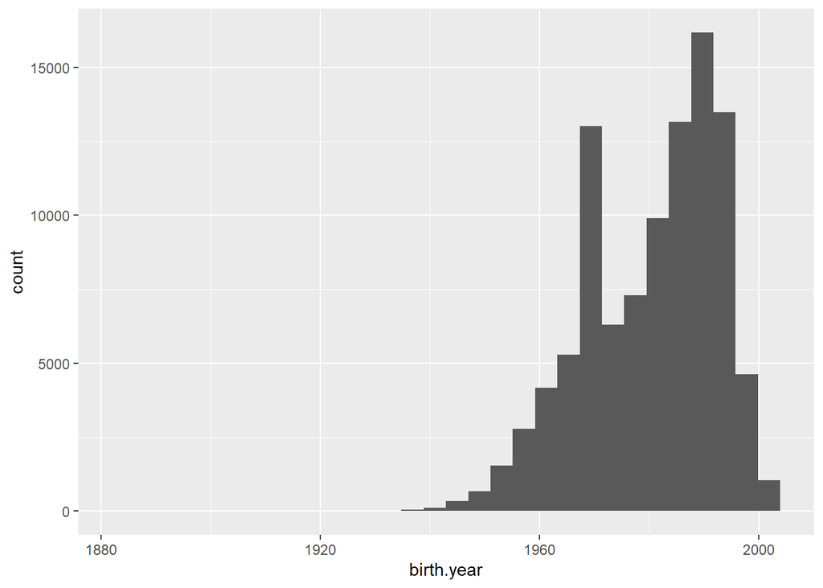

```r
# Birth year histogram
birth_hist <- ggplot(total_sample, aes(x=birth.year,)) + geom_histogram(bins = 30)
birth_hist
```

This histogram shows us that the majority of bikers are younger. There are some very large outliers, but the years of those outliers lead me to believe they aren’t legitimate, as no one born in the 1800s would be alive or riding a bike in 2019. Without the outliers, the graph would be relatively normally distributed with a slight skew left, making complete sense as younger people will bike more than older people.

### Trip Duration

```r
# Average length of a bike ride
duration_mean <- mean(total_sample$tripduration, na.rm=TRUE)
duration_mean
```

```
## [1] 950.8136
```

```r
# Standard deviation of bike rides
duration_sd <- sd(total_sample$tripduration, na.rm=TRUE)
duration_sd
```

```
## [1] 10109.37
```

```r
# Range of all bike rides
duration_range <- range(total_sample$tripduration, na.rm=TRUE)
duration_range
```

```
## [1]      61 2769536
```

### Subscribers

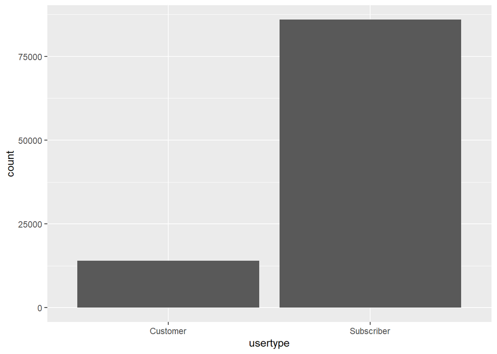

```r
# Seeing the split of user type who rented bikes
subscriber_split <- ggplot(total_sample, aes(x=usertype)) + geom_bar()
subscriber_split
```

This gives us an idea of how many users actually have subscriptions to the bike service, allowing us to know if a subscription service is smart or not. From this result, it seems smart to have.

### Bike ID

```r
# Seeing the distribution of the bikes used
bike_tally <- tally(group_by(total_sample, bikeid), sort=TRUE)
bike_tally[1:5, 1:2]
```

```
## # A tibble: 5 x 2
##   bikeid     n
##    <int> <int>
## 1  35031    24
## 2  30594    23
## 3  31417    23
## 4  34177    23
## 5  34200    23
```

The most used bikes have IDs 35031, 30594, 31417, 34177, and 34200 respectively. The IDs are not all close together in number, leading me to believe the bikes are not in close proximity to each other in geo-location. This info could be used to determine which bikes need to be replaced by number of uses per region.

## Exploratory Data Analysis

### Which bikes are used in which months?

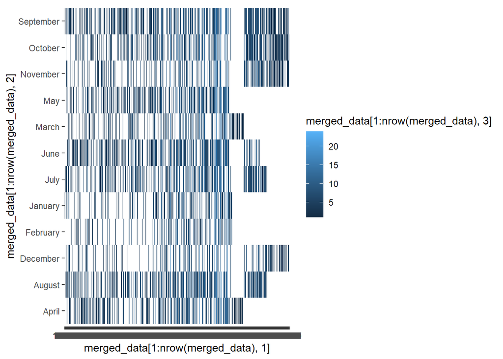

```r
# Finding the month of bikes
heatmap_x <- total_sample[1:nrow(total_sample), c("bikeid", "starttime")]
heatmap_x$starttime <- months(as.Date(total_sample$starttime))
heatmap_y <- tally(group_by(total_sample, bikeid))
merged_data <- merge(heatmap_x, heatmap_y, by='bikeid')
merged_data$bikeid <- as.character(merged_data$bikeid)

# Heatmap
bike_heatmap <- ggplot(total_sample, aes(x=merged_data[1:nrow(merged_data), 1], y=merged_data[1:nrow(merged_data), 2], fill=merged_data[1:nrow(merged_data), 3])) + geom_tile()
bike_heatmap
```

The heat map was supposed to show the use of each bike by its ID. The significance of this would be to give a visual representation of bikes that have been overused to know if they should be replaced or not. It could also be used to see where the bikes are located by ID and used to determine which locations have higher use of bikes. Due to so many bike IDs being present, the x-axis being illegible, making this graph not entirely helpful.

### Which months had more bike us on average?

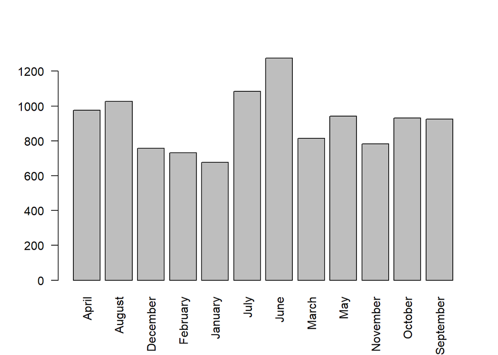

```r
# Barplot of average bike use per month
bike_use_per_month <- round(tapply(total_sample$tripduration, months(as.Date(total_sample$starttime)), mean, na.rm=TRUE), )

barplot(bike_use_per_month, las=2)
```

The months with the most use are the Spring/Summer months. The largest use time in June could be an indication of more people being available to rent bikes for Summer vacation. The increased use of April through August could be people just out an about enjoying warm weather. We don’t see a huge decrease in use in the Winter months, indicating bikes are relatively important for travel to work or other functions.

### Which ages travel longer?

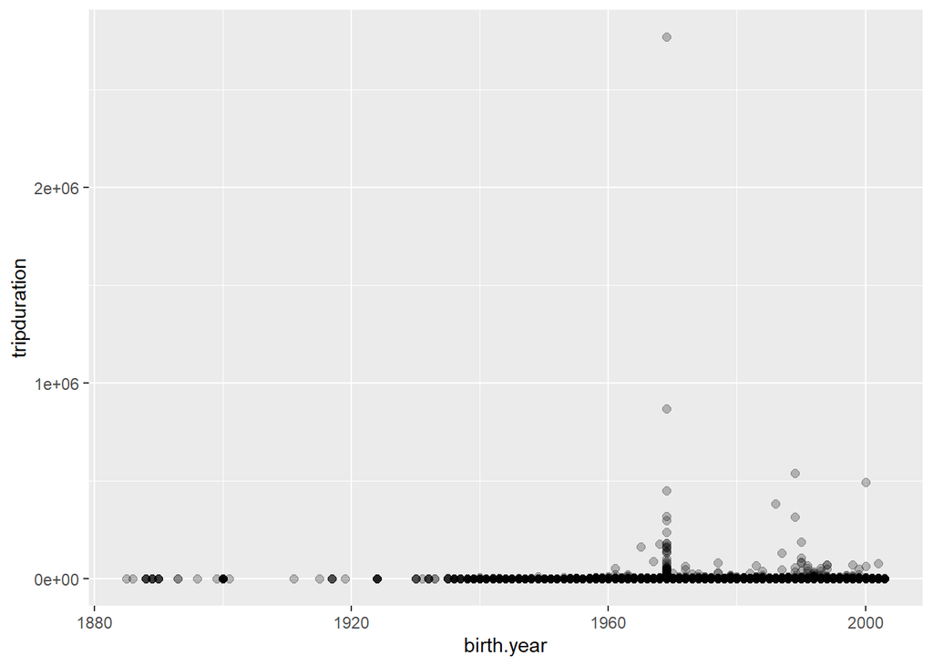

```r
#Scatterplot of ages vs. duration
ages_dist_scatter <- ggplot(total_sample, aes(x=birth.year, y=tripduration)) + geom_point(size=2, alpha=.25)
ages_dist_scatter
```

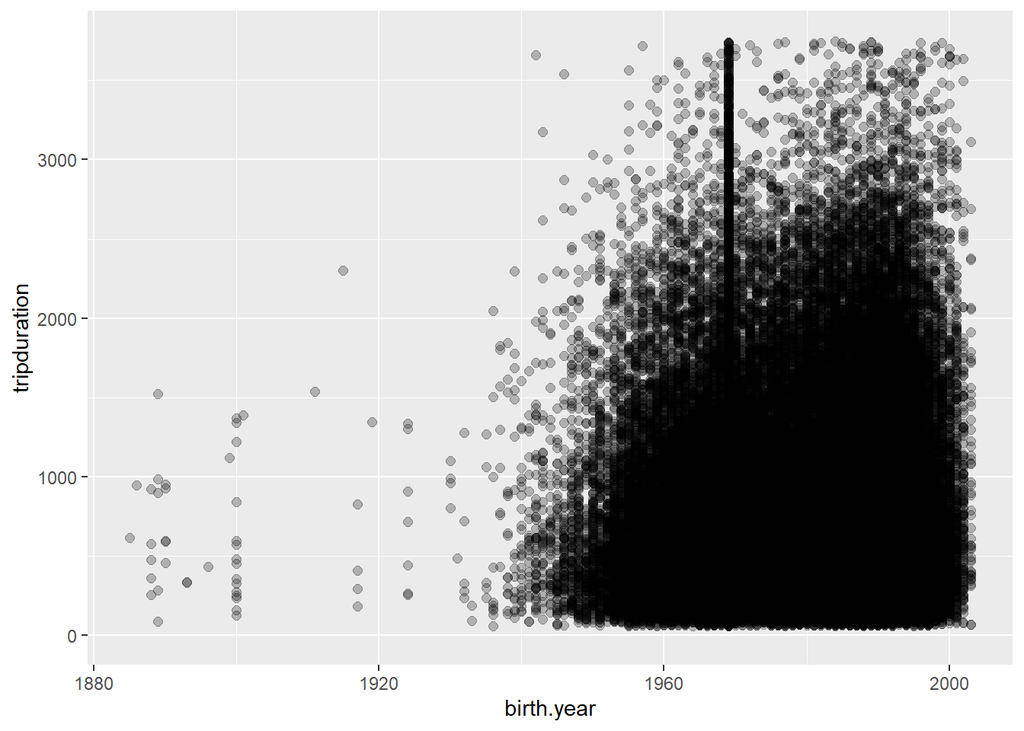

```r
#Scatterplot of ages vs. duration with reduced y-axis
ages_dist_scatter_2 <- ggplot(total_sample, aes(x=birth.year, y=tripduration)) + geom_point(size=2, alpha=.25) + ylim(0,3750)
ages_dist_scatter_2
```

I included both scatterplots, one with outliers and one without, just to show the full effect of the visualization. As we can see, the younger people are, the higher their trip durations go, and the older people are, the lower their highest trip durations tend to go. This scatterplot could also be an indication that more younger people use bikes than older people.

### Which gender travels longer?

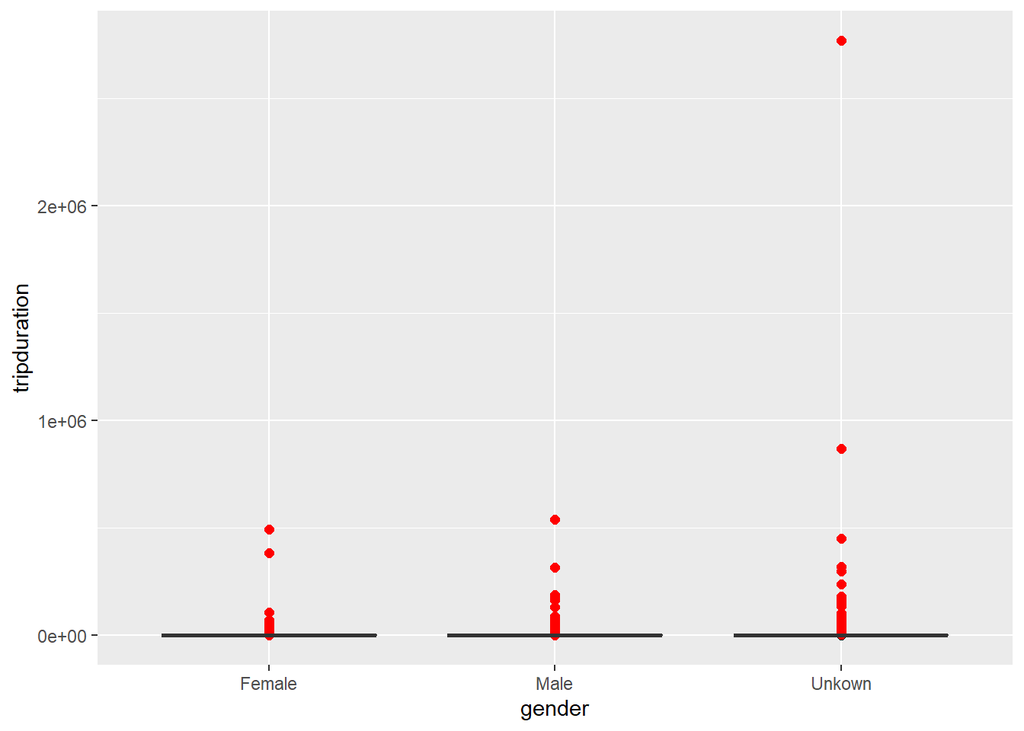

```r
# Boxplot of gender vs. trip duration
gender_dist_box <- ggplot(total_sample, aes(x=gender, y=tripduration, group=gender)) + geom_point(size=2, alpha=0.8) + geom_boxplot(outlier.colour="red", outlier.size=2)
gender_dist_box
```

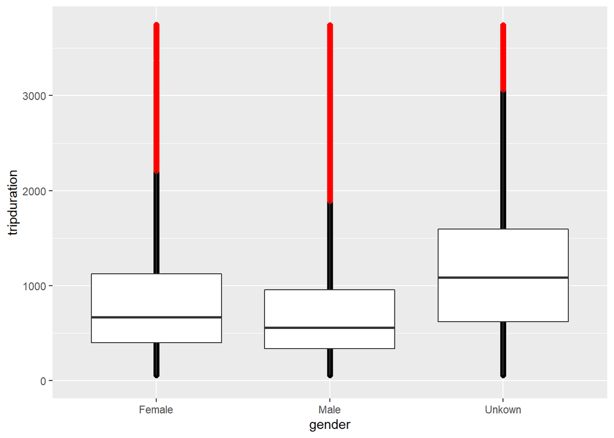

```r
# Boxplot of gender vs. trip duration with reduced y-axis
gender_dist_box_2 <- ggplot(total_sample, aes(x=gender, y=tripduration, group=gender)) + geom_point(size=2, alpha=0.8) + geom_boxplot(outlier.colour="red", outlier.size=2) + ylim(0,3750)
gender_dist_box_2
```